# Introduction to Computing

Computing Bootcamp | From biological questions to repeatable analyses

## Introduction to Computing

### From biological questions to repeatable analyses

**Computing Bootcamp**

Today: why compute, why Linux/*nix, and what happens in a terminal.

**No programming experience assumed.**

## Start with a biological question

**Does plant diversity differ between woodland and grassland?**

- You have observations from several sites.
- The files contain inconsistent names and missing measurements.
- Next week, another 100 sites arrive.

**How would you repeat the analysis and explain every step?**

## From algorithm to program

**Algorithm:** a clear, ordered sequence of steps for solving a problem.

**Program:** those steps expressed as instructions a computer can run.

Read more in the book: [What is an algorithm?](https://mulquabio.github.io/MQB/notebooks/python.html#what-is-an-algorithm).

**Question → algorithm (steps) → program (code) → results → scientific judgement**

1. Read the observations.
2. Check names, units and missing values.
3. Calculate a summary and draw a figure.
4. Check whether the result makes biological sense.

Save the instructions: **inspect, correct, rerun, share.**

## What is doing the work?

| Part | Job |
| --- | --- |
| **Processor (CPU)** | Carries out instructions |
| **Memory (RAM)** | Holds the data and work currently in use |
| **Storage** | Keeps saved files after a program closes |
| **Operating system (OS)** | Manages hardware, files and running programs |

Linux and macOS are operating systems; R and Python are programming languages.

## Terminal, shell, command: three different things

- **Terminal:** the application where you type and see text.
- **Shell:** the program interpreting your commands, such as Bash or Zsh.
- **Command:** an instruction to run a tool or a shell operation.

```
you type a command → the shell acts → output appears
```

The terminal is another way to use your computer, alongside windows and menus.

## Why Linux/*nix?! First, the names

- **Unix:** an influential operating-system family with decades of history.
- **Unix-like (*nix):** systems sharing many Unix ideas and interfaces.
- **Linux:** a Unix-like system; **Ubuntu** is one Linux distribution.
- **macOS:** has Unix foundations and many familiar command-line tools.

**Different systems, many transferable skills.**

## Why Linux/*nix?! The scientific payoff

| Capability | Why it helps a biologist |
| --- | --- |
| Plain-text data and scripts | Inspect how observations become results |
| Small tools that connect | Filter data, then pass it to another tool |
| Saved commands and scripts | Rerun a workflow when new sites arrive |
| Multiple users and jobs | Share a server while simulations run |
| Network and remote access | Work on a computing cluster from your laptop |
| Scientific tools and help | Find software, documentation and examples |

**Learn locally; reuse the skills on larger systems.**

**“No viruses”?** No: Linux and macOS can get malware. Install trusted software and keep it updated.

## Files have addresses

A **directory** is a folder. A **path** tells the computer where to look.

```
project/
  code/       saved analysis instructions
  data/       input observations
  results/    generated tables and figures
```

- `data/survey.csv`: relative to your **current directory**.
- `/`: the filesystem root; `~`: your home directory; `..`: the parent.
- Use consistent names and exact capitalisation.

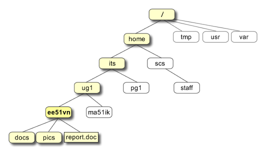

A Unix filesystem branches from the root directory into nested directories.

Directory tree: [Pathan Ruet](https://pathanruet.files.wordpress.com/2012/05/unix-tree.png)

## Read a command from left to right

```bash
head -n 4 data/computing-demo.csv
```

| Piece | Meaning |
| --- | --- |
| `head` | Show the beginning of a file |
| `-n 4` | An option: show four lines |
| `data/computing-demo.csv` | The file to read |

A prompt such as `$` or `%` is **not part of the command**.

## Two-minute terminal demo

**Question: how many observation rows are labelled woodland?**

```bash
pwd
ls
head -n 4 data/computing-demo.csv
grep '^woodland,' data/computing-demo.csv
```

`pwd`: where am I? · `ls`: what is here? · `grep`: which lines match?

**These commands inspect data; they do not change it.**

## Small tools can work together

```bash
grep '^woodland,' data/computing-demo.csv | wc -l
```

**Matching rows → pipe `|` → line counter**

Expected count: **3 observation rows**.

Not three sites. Not three species. Not a test of habitat differences.

## Why learn more than one language?

| Tool | A useful role in our workflow |
| --- | --- |
| **Shell / Bash** | Organise files and connect programs |
| **R** | Analyse data, fit models and visualise results |
| **Python** | Process data, simulate systems and build tools |
| **Git** | Record changes to code and collaborate |

**Choose for the question and the team, not a language rivalry.**

## Habits that protect your science

- Keep raw data unchanged; save code and results separately.
- Test on a small example; check the output.
- Record steps, software versions and assumptions.
- Keep backups; inspect unfamiliar commands before running them.

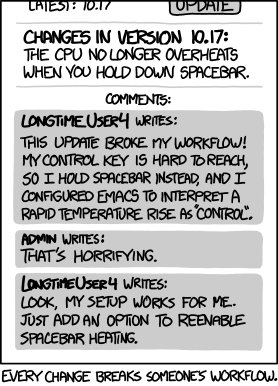

A user reports that a software change broke an elaborate personal workflow.

[xkcd: Workflow](https://xkcd.com/1172/) · Randall Munroe · [CC BY-NC 2.5](https://creativecommons.org/licenses/by-nc/2.5/)

## Check your understanding

1. Why save instructions instead of relying on memory?
2. What does `data/computing-demo.csv` depend on?
3. Does a result of `3` prove woodland has greater diversity?

**The computer follows instructions. You remain responsible for the science.**

## Tasks for today

Work through the [MQB Unix chapter](https://mulquabio.github.io/MQB/notebooks/unix.html). Start with its first two hands-on sections:

1. **Exploring files and directories:** try `ls`, `ls /`, `ls -a` and `ls -l`. Explain what changes.
2. **Building your coursework directory structure:** make one coursework project root with `code`, `data`, `results` and an optional `sandbox` directory inside it.

Use your own workspace name, not the chapter’s example. **Questions?**